# Introduction to crandep

2023-08-17

This vignette provides an introduction to the functions facilitating the analysis of the dependencies of CRAN packages, specifically `get_dep()`, `df_to_graph()` and `topo_sort_kahn()`.

```r
library(crandep)
library(dplyr)
library(igraph)
```

## One or multiple types of dependencies

To obtain the information about various kinds of dependencies of a package, we can use the function `get_dep()` which takes the package name and the type of dependencies as the first and second arguments, respectively. Currently, the second argument accepts a character vector of one or more of the following words: `Depends`, `Imports`, `LinkingTo`, `Suggests`, `Enhances`, or any variations in their letter cases, or if `LinkingTo` is written as `Linking_To` or `Linking To`.

```r
get_dep("dplyr", "Imports")
```

```
#>     from         to    type reverse
#> 1  dplyr        cli imports   FALSE
#> 2  dplyr   generics imports   FALSE
#> 3  dplyr       glue imports   FALSE
#> 4  dplyr  lifecycle imports   FALSE
#> 5  dplyr   magrittr imports   FALSE
#> 6  dplyr    methods imports   FALSE
#> 7  dplyr     pillar imports   FALSE
#> 8  dplyr         R6 imports   FALSE
#> 9  dplyr      rlang imports   FALSE
#> 10 dplyr     tibble imports   FALSE
#> 11 dplyr tidyselect imports   FALSE
#> 12 dplyr      utils imports   FALSE
#> 13 dplyr      vctrs imports   FALSE
```

```r
get_dep("MASS", c("depends", "suggests"))
```

```
#>   from        to     type reverse
#> 1 MASS grDevices  depends   FALSE
#> 2 MASS  graphics  depends   FALSE
#> 3 MASS     stats  depends   FALSE
#> 4 MASS     utils  depends   FALSE
#> 5 MASS   lattice suggests   FALSE
#> 6 MASS      nlme suggests   FALSE
#> 7 MASS      nnet suggests   FALSE
#> 8 MASS  survival suggests   FALSE
```

For more information on different types of dependencies, see [the official guidelines](https://cran.r-project.org/doc/manuals/r-release/R-exts.html#Package-Dependencies) and https://r-pkgs.org/description.html.

In the output, the column `type` is the type of the dependency converted to lower case. Also, `LinkingTo` is now converted to `linking to` for consistency.

```r
get_dep("xts", "LinkingTo")
```

```
#>   from  to       type reverse
#> 1  xts zoo linking to   FALSE
```

```r
get_dep("xts", "linking to")
```

```
#>   from  to       type reverse
#> 1  xts zoo linking to   FALSE
```

For the reverse dependencies, instead of including the prefix “Reverse” in `type`, we use the argument `reverse`:

```r
get_dep("abc", c("depends", "depends"), reverse = TRUE)
```

```
#>   from       to    type reverse
#> 1  abc abctools depends    TRUE
#> 2  abc  EasyABC depends    TRUE
```

```r
get_dep("xts", c("linking to", "linking to"), reverse = TRUE)
```

```
#>   from      to       type reverse
#> 1  xts RcppXts linking to    TRUE
#> 2  xts     TTR linking to    TRUE
```

Theoretically, for each forward dependency

```
#>   from to type reverse
#> 1    A  B    c   FALSE
```

there should be an equivalent reverse dependency

```
#>   from to type reverse
#> 1    B  A    c    TRUE
```

Aligning the `type` in the forward and reverse dependencies enables this to be checked easily.

To obtain all types of dependencies, we can use `"all"` in the second argument, instead of typing a character vector of all 5 words:

```r
df0.rstan <- get_dep("rstan", "all")
dplyr::count(df0.rstan, type)
```

```
#>         type  n
#> 1    depends  1
#> 2    imports 10
#> 3 linking to  5
#> 4   suggests 12
```

```r
df1.rstan <- get_dep("rstan", "all", reverse = TRUE) # too many rows to display
dplyr::count(df1.rstan, type) # hence the summary using count()
```

```
#>         type   n
#> 1    depends  14
#> 2   enhances   3
#> 3    imports 183
#> 4 linking to 142
#> 5   suggests  62
```

## Building and visualising a dependency network

To build a dependency network, we have to obtain the dependencies for multiple packages. For illustration, we choose the [core packages of the tidyverse](https://tidyverse.org/packages/), and find out what each package `Imports`. We put all the dependencies into one data frame, in which the package in the `from` column imports the package in the `to` column. This is essentially the edge list of the dependency network.

```r
df0.imports <- rbind(
  get_dep("ggplot2", "Imports"),
  get_dep("dplyr", "Imports"),
  get_dep("tidyr", "Imports"),
  get_dep("readr", "Imports"),
  get_dep("purrr", "Imports"),
  get_dep("tibble", "Imports"),
  get_dep("stringr", "Imports"),
  get_dep("forcats", "Imports")
)
head(df0.imports)
```

```
#>      from        to    type reverse
#> 1 ggplot2       cli imports   FALSE
#> 2 ggplot2 grDevices imports   FALSE
#> 3 ggplot2      grid imports   FALSE
#> 4 ggplot2    gtable imports   FALSE
#> 5 ggplot2   isoband imports   FALSE
#> 6 ggplot2 lifecycle imports   FALSE
```

```r
tail(df0.imports)
```

```
#>       from        to    type reverse
#> 72 forcats       cli imports   FALSE
#> 73 forcats      glue imports   FALSE
#> 74 forcats lifecycle imports   FALSE
#> 75 forcats  magrittr imports   FALSE
#> 76 forcats     rlang imports   FALSE
#> 77 forcats    tibble imports   FALSE
```

With the help of the ‘igraph’ package, we can use this data frame to build a graph object that represents the dependency network.

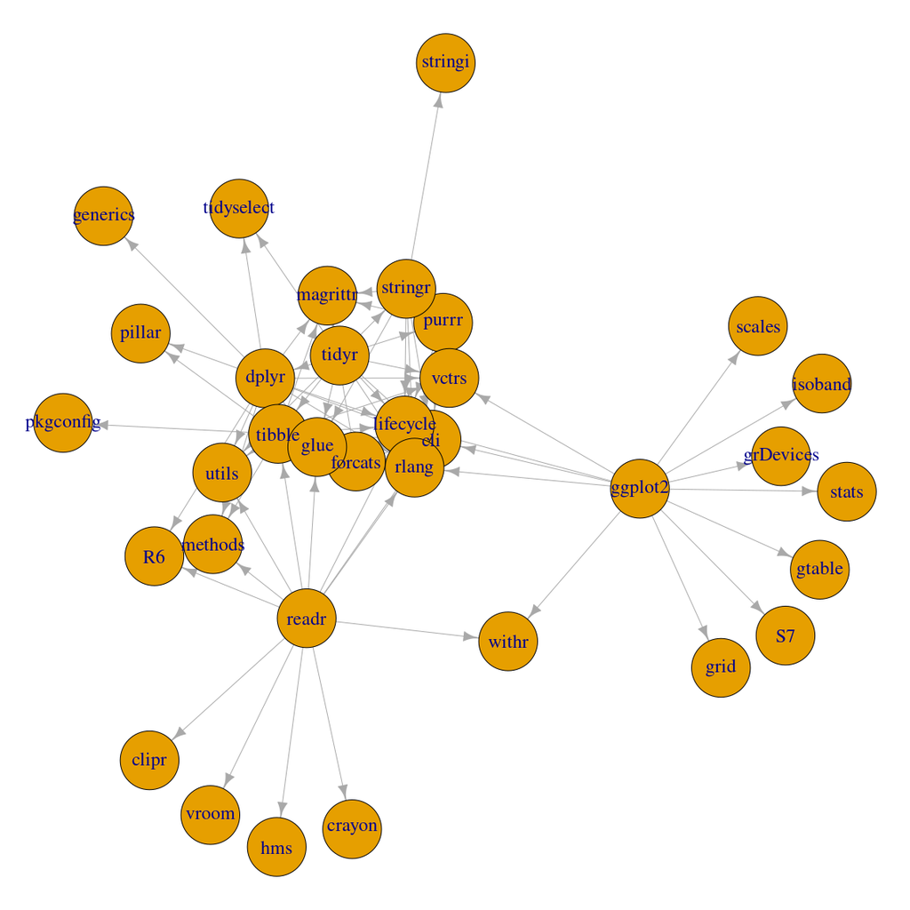

```r
g0.imports <- igraph::graph_from_data_frame(df0.imports)
set.seed(1457L)
old.par <- par(mar = rep(0.0, 4))
plot(g0.imports, vertex.label.cex = 1.5)
par(old.par)
```

The nature of a dependency network makes it a directed acyclic graph (DAG). We can use the ‘igraph’ function `is_dag()` to check.

```r
igraph::is_dag(g0.imports)
```

```
#> [1] TRUE
```

Note that this applies to `Imports` (and `Depends`) only due to their nature. This acyclic nature does not apply to a network of, for example, `Suggests`.

## Boundary and giant component

It is possible to set a boundary on the nodes to which the edges are directed, using the function `df_to_graph()`. The second argument takes in a data frame that contains the list of such nodes in the column `name`.

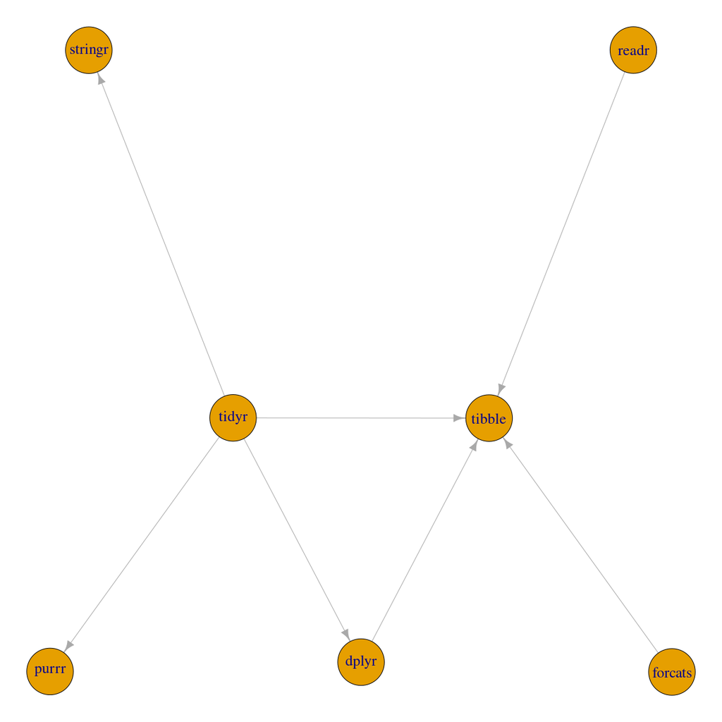

```r
df0.nodes <-
  data.frame(
    name = c("ggplot2", "dplyr", "tidyr", "readr", "purrr", "tibble", "stringr", "forcats"),
    stringsAsFactors = FALSE
  )
g0.core <- df_to_graph(df0.imports, df0.nodes)
set.seed(259L)
old.par <- par(mar = rep(0.0, 4))
plot(g0.core, vertex.label.cex = 1.5)
par(old.par)
```

## Topological ordering of nodes

Since networks according to `Imports` or `Depends` are DAGs, we can obtain the [topological ordering](https://en.wikipedia.org/wiki/Topological_sorting) using, for example, [Kahn’s (1962) sorting algorithm](https://doi.org/10.1145/368996.369025).

```r
topo_sort_kahn(g0.core)
```

```
#>        id id_num
#> 1 forcats      1
#> 2   readr      2
#> 3   tidyr      3
#> 4   dplyr      4
#> 5   purrr      5
#> 6 stringr      6
#> 7  tibble      7
```

In the topological ordering, represented by the column `id_num`, a low (high) number represents being at the front (back) of the ordering. If package A `Imports` package B i.e. there is a directed edge from A to B, then A will be topologically before B. As the package ‘tibble’ doesn’t import any package but is imported by most other packages, it naturally goes to the back of the ordering. This ordering may not be unique for a DAG, and other admissible orderings can be obtained by setting `random=TRUE` in the function:

```r
set.seed(387L); topo_sort_kahn(g0.core, random = TRUE)
```

```
#>        id id_num
#> 1   readr      1
#> 2   tidyr      2
#> 3 forcats      3
#> 4   purrr      4
#> 5   dplyr      5
#> 6  tibble      6
#> 7 stringr      7
```

We can also apply the topological sorting to the bigger dependencies network.

```r
df0.topo <- topo_sort_kahn(g0.imports)
head(df0.topo)
```

```
#>          id id_num
#> 1   forcats      1
#> 2   ggplot2      2
#> 3     readr      3
#> 4     tidyr      4
#> 5 grDevices      5
#> 6      grid      6
```

```r
tail(df0.topo)
```

```
#>           id id_num
#> 29   methods     29
#> 30    pillar     30
#> 31 pkgconfig     31
#> 32     rlang     32
#> 33     utils     33
#> 34     vctrs     34
```

## Going forward

In this other vignette, we show how to obtain the dependency network of **all** CRAN packages using other functions in the package. The number of reverse dependencies can then be modelled.